# Section 1: Information about the file -

1. Total records

```
8831779
```

1. Number of Columns (Data Columns)

```
20
```

1. Column Names and Data Type

```
Index(['District', 'Janpad', 'Gram Panchayat', 'Village',
       'Name of head of household', 'GOI ID', 'Column_1', 'Economic status',
       'Sub-category', 'Has Toilet', 'Type of toilet', 'Has Water Source',
       'Water source', 'State', '% Headed by Women', '% Headed by PWD',
       '% Having No Toilet', '% Having No Water Source', 'Total Household',
       '% Households having Toilet but no Water Source'],
      dtype='object')
```

# Section 2: Snapshot of the data -

```
Districts:  51   |  Janpad:  311   |  Gram Panchayats:  18286   |  Villages:  36347   |  Surveys:  8831779
```

## Does the data contain any empty cell?

```
True - Yes
False - No
```

```python
raw_data.empty
```

```
False
```

## Identify duplicate records

Based on the combination - District+Janpad+Gram Panchayat+Village+Name of head of household+GOI ID

```python
raw_data["is_duplicate_record"] = raw_data.duplicated(subset=("District",
             "Janpad",
             "Gram Panchayat",
             "Village",
             "Name of head of household",
             "GOI ID"),
                                                     keep='last')
```

# Section 3: Data Error Checks

## 1. Total Duplicate records:

```
65222
```

*Deduplicating the data*

**Number of unique Records -**

```
8766557
```

## 2. Missing Data in Mandatory Columns:

```
-----
Series([], Name: Column_1, dtype: int64)
Missing Data:  8766557
```

### Observations:

a. All the values in Column_1 are missing. b. There is no other missing value error.

## 3. Number of records where toilet is available in the household but type of toilet has either not been provided or mentioned as not available -

```python
"""Data Error Condition 3: Number of Records where toilet is available but type of toilet has been mentioned उपलब्ध नहीं है"""
total_hh=np.sum(raw_data['Total Household'])

raw_data_tlt_nttype = raw_data[(raw_data["Has Toilet"] == 'हाँ') & (raw_data["Type of toilet"] == 'उपलब्ध नहीं है')]
x=raw_data_tlt_nttype.shape[0]
y=round(x/total_hh*100,2)
print("No of Records:",x," (",y,"%)")
```

```
No of Records: 8756  ( 0.1 %)
```

## 4. Number of records where toilet is not available in the household but type of toilet has been mentioned -

```python
"""Data Error Condition 4: Number of Records where toilet is not available but type of toilet has been mentioned other than उपलब्ध नहीं है"""
raw_data_ntlt_ttype=raw_data[(raw_data["Has Toilet"] == 'नहीं') & (raw_data["Type of toilet"] != 'उपलब्ध नहीं है')]

x=raw_data_ntlt_ttype.shape[0]
y=round(x/total_hh*100,2)
print("No of Records:",x," (",y,"%)")
```

```
No of Records: 3262  ( 0.04 %)
```

## 5. Number of records where water source is available in the household but type of source has either not been provided or mentioned as not available -

```python
"""Data Error Condition 3: Number of Records where water source is available but type of source has been mentioned as not available"""
raw_data_ws_nwstype=raw_data[(raw_data["Has Water Source"] == 'हाँ') & ((raw_data["Water source"] == 'उपलब्ध नहीं है') | (raw_data["Water source"] == 'पानी का कोई स्त्रोत नहीं'))]
x=raw_data_ws_nwstype.shape[0]
y=round(x/total_hh*100,2)
print("No of Records:",x," (",y,"%)")
```

```
No of Records: 321556  ( 3.67 %)
```

## 6. Number of records where water source is not available in the household but type of source has been provided -

```python
"""Data Error Condition 3: Number of Records where water source is not available but type of source has been mentioned as available"""
raw_data_nws_wstype=raw_data[(raw_data["Has Water Source"] == 'नहीं') & (raw_data["Water source"] != 'उपलब्ध नहीं है') & (raw_data["Water source"] != 'पानी का कोई स्त्रोत नहीं')]

x=raw_data_nws_wstype.shape[0]
y=round(x/total_hh*100,2)
print("No of Records:",x," (",y,"%)")
```

```
No of Records: 792292  ( 9.04 %)
```

# Section 2: Data Analysis

## 1. Overview

### Total Households Surveyed in Verification:

```
8766557
```

### Households by Economic Status

```
Number of households by Economic Status
-----------------------
     Total Households      %
BPL           4448441  50.74
APL           4318116  49.26
```

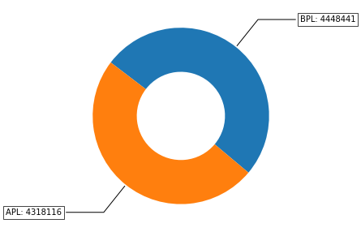

#### Observations:

1. Distribution of households by economic status is quite even, i.e. there are almost 50% BPL and 50% APL families where verification of toilet has been conducted.

### Households by Social Category

```
Number of households in
-----------------------
ST                                  2185368
GENERAL                             2082756
Other                               1987984
SC                                  1310257
Small & Marginal Farmers             895338
Women Headed HH                      203653
Landless with homestead               74495
Headed by Person with Disability      26706
Name: Sub-category, dtype: int64
-----------------------
% of households in
-----------------------
ST                                  24.928464
GENERAL                             23.757970
Other                               22.676907
SC                                  14.946084
Small & Marginal Farmers            10.213109
Women Headed HH                      2.323067
Landless with homestead              0.849763
Headed by Person with Disability     0.304635
Name: Sub-category, dtype: float64
-----------------------
```

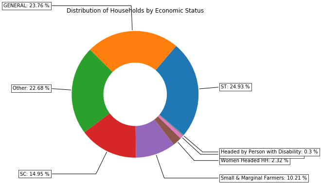

### Households by Economic Status and Social Category

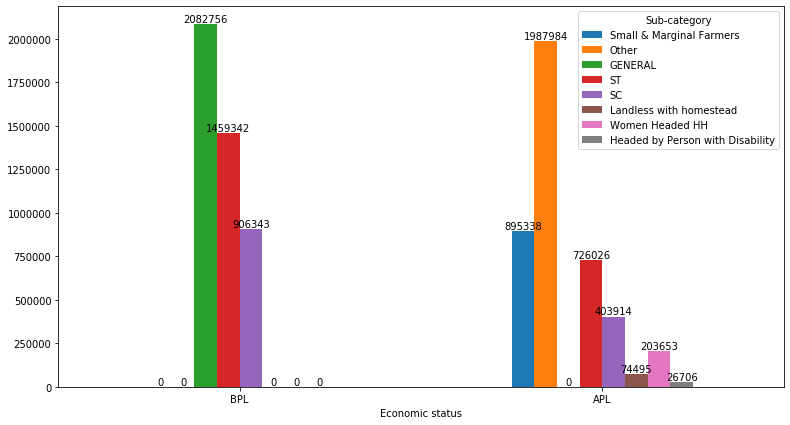

#### Observations -

1. There are 22.7% households in "Others" category
2. All the General category households are BPL
3. BPL Households has only General, SC and ST category. No landless family, or household headed by a woman or physically challenged person has been reported as BPL.

## 2. Status of Toilets in Households

### Availability of Toilets in the Households

```
Number of households having toilet
-----------------------
Yes    8315353
No      451204
Name: Has Toilet, dtype: int64
-----------------------
```

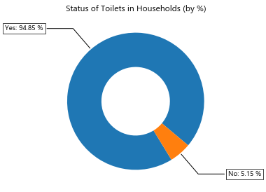

```
Number of Household having toilet(or not) by Economic Status:
```

| Has Toilet Economic status | Yes | No |
| --- | --- | --- |
| BPL | 4205129 | 243312 |
| APL | 4110224 | 207892 |

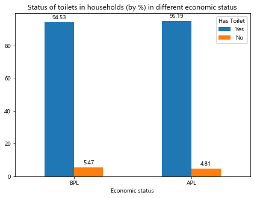

```
Number of Household having toilet(or not) by Social Category:
```

| Sub-category Has Toilet | Small & Marginal Farmers | Other | GENERAL | ST | SC | Landless with homestead | Women Headed HH | Headed by Person with Disability |
| --- | --- | --- | --- | --- | --- | --- | --- | --- |
| Yes | 864974 | 1870337 | 1975332 | 2063184 | 1249649 | 72033 | 194271 | 25573 |
| No | 30364 | 117647 | 107424 | 122184 | 60608 | 2462 | 9382 | 1133 |

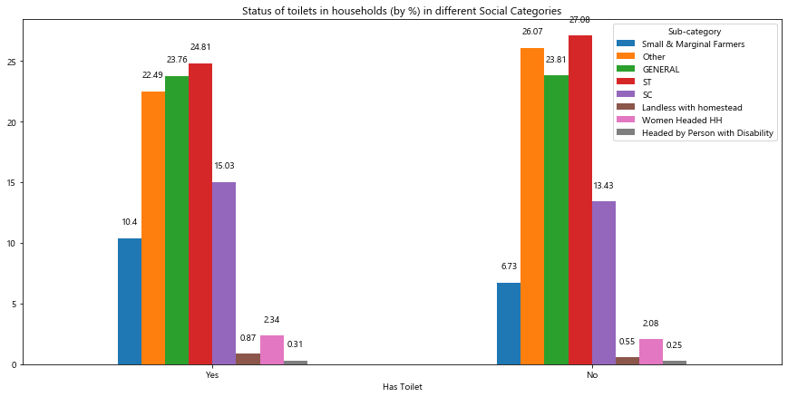

#### Observations:

1. 94.85% of the housheolds have toilet
2. However 4.55 lakh households are still devoid of toilet facility. ST households are the most affected

### Availabilty of Different Types of Toilet across Households

```python
hh_with_toilet = raw_data[(raw_data["Has Toilet"] == 'हाँ') & (raw_data["Type of toilet"] != 'उपलब्ध नहीं है')]
```

```python
print("Number of households having different types toilet")
print("--------------------------------------------------")
hh_hvng_tlt_type_cnt = hh_with_toilet["Type of toilet"].apply(lambda x: "Single Pit" if x=="एक गड्ढे वाला" else ("Double Pit" if x=="दो गड्ढे वाला" else ("Septic Tank" if x=="सेप्टिक टैंक" else ("Septic Tank with Soak Pit" if x=="सोखते गड्ढे के साथ सेप्टिक टैंक" else ("Bio Toilet" if x== "बायो-शौचालय" else "Not Available"))))).value_counts()
print(hh_hvng_tlt_type_cnt)
print("--------------------------------------------------")
```

```
Number of households having different types toilet
--------------------------------------------------
Single Pit                   3727702
Double Pit                   2636584
Septic Tank                  1586399
Septic Tank with Soak Pit     342754
Bio Toilet                     13158
Not Available                      0
Name: Type of toilet, dtype: int64
--------------------------------------------------
```

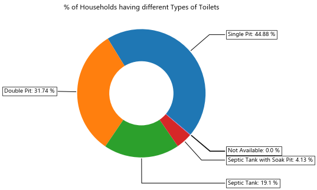

```python
display_donut(hh_with_toilet["Type of toilet"].apply(lambda x: "Single Pit" if x=="एक गड्ढे वाला" else ("Double Pit" if x=="दो गड्ढे वाला" else ("Septic Tank" if x=="सेप्टिक टैंक" else ("Septic Tank with Soak Pit" if x=="सोखते गड्ढे के साथ सेप्टिक टैंक" else ("Bio Toilet" if x== "बायो-शौचालय" else "Not Available"))))),
              width=5,
              height=5,
              title="% of Households having different Types of Toilets",
              pct=True)
```

## 3. Status of Water Sources in the Households

### Availability of Water Source in the Households

```python
print("Number of households having water source")
print("-----------------------")
display(raw_data["Has Water Source"].apply(lambda x: "Yes" if x=="हाँ" else "No").value_counts())
```

```
Number of households having water source
-----------------------
```

```
Yes    7781886
No      984671
Name: Has Water Source, dtype: int64
```

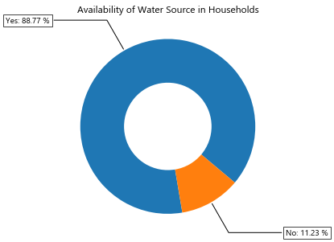

```python
display_donut(raw_data["Has Water Source"].apply(lambda x: "Yes" if x=="हाँ" else "No"),
              width=5,
              height=5,
              title="Availability of Water Source in Households",
              pct=True)
```

**Availability of water source in households across different economic status**

| Has Water Source Economic status | Yes | No |
| --- | --- | --- |
| BPL | 3875688 | 572753 |
| APL | 3906198 | 411918 |

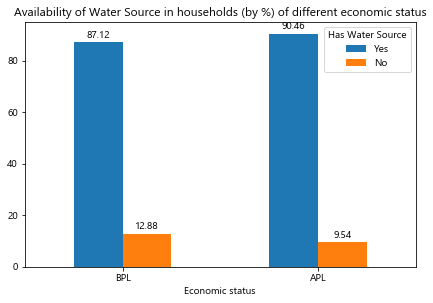

**Availability of water source in households across different social strata**

| Sub-category Has Water Source | Small & Marginal Farmers | Other | GENERAL | ST | SC | Landless with homestead | Women Headed HH | Headed by Person with Disability |
| --- | --- | --- | --- | --- | --- | --- | --- | --- |
| Yes | 831712 | 1802052 | 1856359 | 1838507 | 1177699 | 68898 | 182543 | 24116 |
| No | 63626 | 185932 | 226397 | 346861 | 132558 | 5597 | 21110 | 2590 |

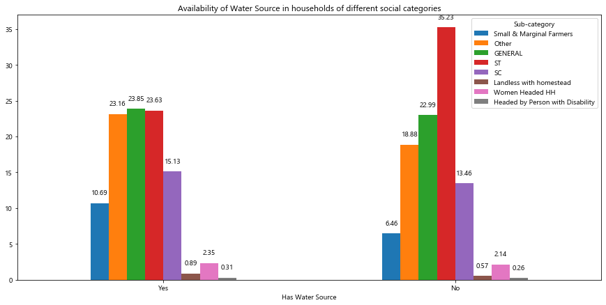

#### Observation:

1. 88.77% of the households have a water source
2. Howerver, around 9.9 Lakh Households don't have water source. ST category households are the worst affected.

### Availabilty of Different Types of Water Sources across Households

```
Number of households having different types of water source
--------------------------------------------------
```

```
Handpump                  4125863
Piped Water Connection    2212615
Well                      1090772
Pond                        31080
No Source of Water              0
Data Missing                    0
Name: Water source, dtype: int64
```

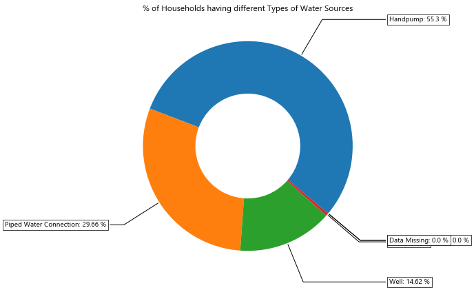

### Availability of Toilets and Water Source in the Households

```
Has Water Source      Yes      No
Has Toilet
Yes               7763026  552327
No                  18860  432344
```

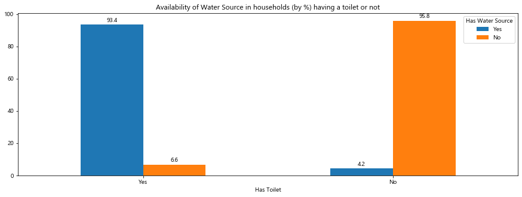

#### Observation:

1. Handpump is the major source of water in households (55% of households use handpumps)
2. Water Supply scheme is available in only 29.7% ~ 30% of the households and the remaining.
3. 14% of the households rely on wells
4. Around 5.56 Lakh households having toilets has no water source

# Section 3: Status of toilets across State and Districts

| State | District | % Having No Toilet | % Having No Water Source | % Headed by PWD | % Headed by Women | % Households having Toilet but no Water Source | Total Household |
| --- | --- | --- | --- | --- | --- | --- | --- |
| Madhya Pradesh | AGAR MALWA | 3.845853 | 6.158323 | 0.147466 | 1.350681 | 2.877538 | 76628 |
|  | ALIRAJPUR | 0.955105 | 3.400175 | 0.150953 | 2.115209 | 2.609068 | 107318 |
|  | ANUPPUR | 3.622540 | 21.902941 | 0.326715 | 4.348959 | 18.365556 | 115085 |
|  | ASHOKNAGAR | 1.019151 | 4.418540 | 0.286428 | 1.736331 | 3.447127 | 90075 |
|  | BALAGHAT | 6.251902 | 12.602423 | 0.152879 | 1.849577 | 6.673144 | 272765 |
|  | BARWANI | 9.328697 | 17.081445 | 0.062654 | 0.917234 | 8.001671 | 177163 |
|  | BETUL | 3.780451 | 8.766939 | 0.282013 | 3.005037 | 5.148830 | 203891 |
|  | BHIND | 2.549590 | 3.219321 | 0.341269 | 3.664955 | 0.868218 | 156182 |
|  | BHOPAL | 1.853633 | 3.540249 | 0.296075 | 1.476580 | 1.725840 | 79034 |
|  | BURHANPUR | 4.768737 | 10.261118 | 0.069513 | 1.126459 | 5.578825 | 112210 |
|  | CHHATARPUR | 9.478522 | 19.991836 | 0.486649 | 3.232664 | 10.987770 | 188637 |
|  | CHHINDWARA | 1.792502 | 5.067089 | 0.448832 | 3.157829 | 3.341128 | 318605 |
|  | DAMOH | 7.700066 | 18.794533 | 0.318069 | 2.645915 | 11.247260 | 200271 |
|  | DATIA | 4.531415 | 5.875132 | 0.217793 | 2.181890 | 1.576030 | 75760 |
|  | DEWAS | 4.208855 | 6.217341 | 0.208915 | 2.097163 | 2.248463 | 199603 |
|  | DHAR | 0.984006 | 2.634272 | 0.171492 | 2.003278 | 1.712156 | 289226 |
|  | DINDORI | 7.840417 | 20.247878 | 0.114591 | 2.052832 | 12.534113 | 132646 |
|  | GUNA | 7.007577 | 16.045387 | 0.205612 | 1.632715 | 9.222861 | 131315 |
|  | GWALIOR | 1.194456 | 1.932657 | 0.235272 | 2.020289 | 0.997285 | 104985 |
|  | HARDA | 1.956833 | 5.527942 | 0.095155 | 0.579885 | 3.657308 | 89328 |
|  | HOSHANGABAD | 2.432492 | 5.951400 | 0.240797 | 1.357392 | 3.648424 | 159055 |
|  | INDORE | 0.333451 | 0.714164 | 0.097804 | 1.063369 | 0.395810 | 152346 |
|  | JABALPUR | 23.240162 | 33.736213 | 0.249176 | 2.147841 | 11.120908 | 182602 |
|  | JHABUA | 1.895834 | 8.201437 | 0.514566 | 1.704267 | 6.442613 | 161301 |
|  | KATNI | 4.108901 | 11.627247 | 0.284802 | 2.208582 | 7.685299 | 183285 |
|  | KHANDWA | 3.773782 | 6.919816 | 0.297189 | 2.939045 | 3.541766 | 191797 |
|  | KHARGONE | 9.144228 | 17.601550 | 0.486559 | 3.117941 | 8.700381 | 227105 |
|  | MANDLA | 8.520620 | 24.418305 | 0.351596 | 3.312638 | 16.174895 | 201652 |
|  | MANDSAUR | 3.004987 | 6.140038 | 0.322194 | 2.754031 | 3.397880 | 185292 |
|  | MORENA | 3.180670 | 4.503610 | 0.385078 | 3.227455 | 1.474812 | 138933 |
|  | NARSINGHPUR | 1.230059 | 3.650320 | 0.347234 | 1.349079 | 2.486870 | 183162 |
|  | NEEMUCH | 2.513809 | 9.073974 | 0.448392 | 2.519225 | 6.849345 | 92330 |
|  | PANNA | 5.981385 | 12.106848 | 0.242051 | 1.845635 | 6.292593 | 138814 |
|  | RAISEN | 3.013914 | 5.627483 | 0.372558 | 1.974971 | 3.076693 | 194332 |
|  | RAJGARH | 7.359165 | 14.525470 | 0.384548 | 2.406941 | 7.577232 | 170590 |
|  | RATLAM | 1.131862 | 3.870884 | 0.247392 | 2.699463 | 2.781534 | 169367 |
|  | REWA | 9.646002 | 18.895277 | 0.258622 | 2.660608 | 9.543649 | 346838 |
|  | SAGAR | 2.098261 | 6.451369 | 0.261104 | 2.385777 | 4.456116 | 265029 |
|  | SATNA | 8.904397 | 22.369955 | 0.275756 | 2.290120 | 13.762182 | 335441 |
|  | SEHORE | 1.253390 | 4.215407 | 0.322131 | 1.163826 | 3.049106 | 202092 |
|  | SEONI | 15.118647 | 27.762732 | 0.567722 | 3.279536 | 13.066010 | 226343 |
|  | SHAHDOL | 1.659107 | 7.109228 | 0.358081 | 2.602716 | 5.531020 | 150804 |
|  | SHAJAPUR | 0.628434 | 1.607461 | 0.190540 | 1.545102 | 1.051778 | 144327 |
|  | SHEOPUR | 1.020194 | 1.553335 | 0.310039 | 2.660466 | 0.853653 | 95472 |
|  | SHIVPURI | 8.490277 | 14.256679 | 0.292099 | 2.560462 | 5.987519 | 195824 |
|  | SIDHI | 4.536944 | 13.285198 | 0.668800 | 3.494918 | 8.930484 | 159689 |
|  | SINGROULI | 4.610230 | 19.384260 | 0.301541 | 2.172586 | 14.868588 | 134310 |
|  | TIKAMGARH | 1.542782 | 3.485013 | 0.630409 | 2.565763 | 2.006992 | 174490 |
|  | UJJAIN | 2.054499 | 3.187568 | 0.194364 | 1.924923 | 1.194498 | 208372 |
|  | UMARIA | 6.991999 | 19.565615 | 0.111693 | 1.301734 | 13.037651 | 98484 |
|  | VIDISHA | 7.959649 | 12.883891 | 0.437194 | 2.203547 | 5.350662 | 176352 |
| All |  | 5.146878 | 11.232129 | 0.304635 | 2.323067 | 6.300387 | 8766557 |

#### Observations

1. In Jabalpur 23.27% of the households do not have toilet, followed by Seoni with 15.1% such households
2. Again, Jabalpur and Seoni are the two districts with highest % of households without any source of water (with 33.75% and 27.78% respectively)
3. Anuppur and Mandala districts have the highest proportion of households having a toilet but no water source (with 18.37% and 16.2% respectively)